# Applied Statistics Project.

## 3. Variety:

- Variety refers to the diversity and range of data types, formats, and sources that are used for analysis.
- In the given data set , we can see there is high amount of correlation between many columns means many columns providing the same information. Ex. Score, BasketScored, BasketGiven etc columns providing the same information. So data set have low level of variety.

#### To improve variety in data analysis, Association can follow below approaches:

1. **Data source diversification:** Association can consider incorporating data from external sources, such as public datasets, third-party data providers etc. This can provide access to diverse datasets and perspectives that enrich the analysis.
2. **Unstructured data analysis:** This will get from text documents, social media posts, emails, or customer reviews.Association can use techniques, like natural language processing (NLP) or sentiment analysis which will allow Association to tap into valuable information contained within unstructured sources.
3. **Data integration and consolidation:** Data integration techniques, like data warehousing or data lakes, can be utilized to bring together diverse data sources and facilitate cross-domain analysis.
4. **Multimedia data analysis:**Techniques like image recognition, audio classification, or video processing can be employed to extract insights from multimedia sources.
5. **Sensor data analysis:** Sensor data can provide Association real-time information about environmental conditions, equipment performance, or user behavior.
6. **Text analytics and sentiment analysis:** Techniques, such as topic modeling or sentiment analysis will help Association to gain insights from textual data.

> > Thus , by improving the variety of data in data analysis, Association can uncover hidden patterns, trends, or relationships

## 4. Velocity:

- Velocity refers to the speed at which data is collected, processed, and analyzed.
- Such tournaments are arranged world wide in specific seasons , so tracing the respective data from the each tournaments will help to improve the association management predicting capability so association should always give importance to speedily collecting the data and processing.

#### To improve velocity in data , Association can consider following strategies:

1. **Automated data collection:** By using web scraping tools etc. to collect data directly will help to reduce manual effort, save time, and ensure a continuous flow of data.
2. **Real-time data processing:** For that , Association management can Streaming platforms or event-driven architectures can be employed to process data as it arrives, allowing for immediate insights and responses. It will association to react swiftly to changing conditions and make real time decisions.
3. **Parallel processing and distributed computing:** Association management can use technologies like Apache Hadoop or Apache Spark which allow for the distribution of computational tasks across multiple nodes, enabling faster data processing and analysis by harnessing the power of multiple machines.
4. **Preprocessing and data transformation:** This can involve using efficient algorithms or techniques to handle missing data, normalize data, or aggregate data.
5. **Cloud computing and scalability:** Cloud-based services like Amazon Web Services (AWS), Microsoft Azure etc offers scalability and on-demand resources. This helps for faster data processing and analysis during peak periods.
6. **Data caching and indexing:** It will help Association management to improve data retrieval speed.
7. **Data pipeline optimization:** This will help Association management to Streamline and optimize the data pipeline to eliminate bottlenecks and reduce processing delays.

> > Thus by implementing these strategies, Association can improve the velocity of data analysis, enabling faster insights and more timely decision-making.

### 5.Veracity:

- Veracity means the accuracy , reliability and trustworthiness of the data being analyzed.

#### Some common challenges related to data veracity includes:

1. Inaccurate or incomplete data
2. Data bias
3. Data integrity and security

#### **To address the veracity concerns , Association should implement the following practices:**

1. **Data validation and cleansing:** It will help to identify and correct errors, inconsistencies, and missing values in the dataset.
2. **Data governance:-** Association should follow robust data governance policies to establish data quality standards,define data ownership and implement data management policies. This will helps ensure accountability, data quality control, and adherence to regulatory requirements.
1. **Data auditing:-** Association should Conduct regular data audits to assess the accuracy, completeness, and consistency of the collected data. This involves evaluating the data against predefined quality metrics and performing checks to identify any potential issues.
2. **Data ethics:** Association management should promote ethical considerations in data collection, storage, and analysis.

> > Thus , by following the above measures , Association can achieve greater confidence in the predictions derived from the data analysis process and make more informed decisions based on trustworthy information.

# Part C - 15 Marks

### • STEPS AND TASK [15 Marks]:

### We will import all the required libraries first.

```python
import numpy as     np
import pandas as     pd
from   scipy.stats import ttest_1samp, ttest_ind
import matplotlib.pyplot as plt
%matplotlib inline
import seaborn as sns
import scipy.stats as stats
import statsmodels.stats.api as sm
```

### 1. Read the CSV file.

## Ans:

```python
df=pd.read_csv("DS_Part3_CompanyX_EU.csv")
```

```python
df.head()
```

|  | Startup | Product | Funding | Event | Result | OperatingState |
| --- | --- | --- | --- | --- | --- | --- |
| 0 | 2600Hz | 2600hz.com | NaN | Disrupt SF 2013 | Contestant | Operating |
| 1 | 3DLT | 3dlt.com | $630K | Disrupt NYC 2013 | Contestant | Closed |
| 2 | 3DPrinterOS | 3dprinteros.com | NaN | Disrupt SF 2016 | Contestant | Operating |
| 3 | 3Dprintler | 3dprintler.com | $1M | Disrupt NY 2016 | Audience choice | Operating |
| 4 | 42 Technologies | 42technologies.com | NaN | Disrupt NYC 2013 | Contestant | Operating |

## 2. Data Exploration: [1 Mark]

### A. Check the datatypes of each attribute

## Ans:

```python
df.dtypes
```

```
Startup           object
Product           object
Funding           object
Event             object
Result            object
OperatingState    object
dtype: object
```

### Observation:

1. All columns have object data type.
2. But Funding columns contains Funds raised by the company in USD. So we treat that column and convert it into numerical column later.

### B. Check for null values in the attributes.

## Ans:

```python
df.isnull().sum()
```

```
Startup             0
Product             6
Funding           214
Event               0
Result              0
OperatingState      0
dtype: int64
```

### Observation:

1. There are 6 null values in Product column and 214 null values in Funding column.
2. We will drop that null values later.

### 3. Data preprocessing & visualisation: [4 Marks]

### A. Drop the null values. [1 Mark]

## Ans:

```python
df1=df.copy() # Before droping the null values , it is best practice to create a copied dataframe.
```

```python
df1.shape
```

```
(662, 6)
```

```python
df.dropna(inplace=True)
```

```python
df.shape
```

```
(446, 6)
```

### Observation:

- In original data frame , there were total 662 rows . After droping null value , we have total 446 values in our new data frame.

### B.Convert the ‘Funding’ features to a numerical value.

```python
df.Funding.sample(5)
```

```
398      $24M
255    $14.1M
285     $1.6M
415     $755K
106     $1.4M
Name: Funding, dtype: object
```

### Observation:

- We can see that in Funding column values are with dollar sign and abbreviations like M for million, K for thousand etc.
- So we need to do some pre-processing to convert it into numerical column.
- For that we use the provided code, which will create one new column having name 'Funds_in_million' from Funding column.

## Ans:

```python
# This below code line is provided to us in project material so we copied it pasted it here.
df.loc[:,'Funds_in_million'] = df['Funding'].apply(lambda x: float(x[1:-1])/1000 if x[-1] == 'K' else (float(x[1:-1])*1000 if x[-1] == 'B' else float(x[1:-1])))
```

```python
df.head()
```

|  | Startup | Product | Funding | Event | Result | OperatingState | Funds_in_million |
| --- | --- | --- | --- | --- | --- | --- | --- |
| 1 | 3DLT | 3dlt.com | $630K | Disrupt NYC 2013 | Contestant | Closed | 0.63 |
| 3 | 3Dprintler | 3dprintler.com | $1M | Disrupt NY 2016 | Audience choice | Operating | 1.00 |
| 5 | 5to1 | 5to1.com | $19.3M | TC50 2009 | Contestant | Acquired | 19.30 |
| 6 | 8 Securities | 8securities.com | $29M | Disrupt Beijing 2011 | Finalist | Operating | 29.00 |
| 10 | AdhereTech | adheretech.com | $1.8M | Hardware Battlefield 2014 | Contestant | Operating | 1.80 |

```python
df.dtypes
```

```
Startup              object
Product              object
Funding              object
Event                object
Result               object
OperatingState       object
Funds_in_million    float64
dtype: object
```

### C. Plot box plot for funds in million. [1 Mark]

## Ans:

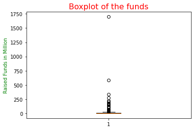

```python
%matplotlib inline
plt.boxplot(df.Funds_in_million)
plt.title('Boxplot of the funds',fontsize=16,color='r')
plt.ylabel("Raised Funds in Million",color='g')
plt.show();
```

### Observations:

- There are many outliers.
- So we will have to treat them so that we can use it for later processing.

### D. Check the number of outliers greater than the upper fence. [1 Mark]

## Ans:

```python
q1 = np.percentile(df.Funds_in_million, 25)
q3 = np.percentile(df.Funds_in_million, 75)
iqr = q3 - q1
#lower_fence = q1 - k * iqr
upper_fence = q3 + 1.5 * iqr
print(f'Upper fence value is : {upper_fence}')
print("#"*40)

df_outliers = df[df.Funds_in_million > 22.569625]

print(f'Total number of outliers are: --> = {df[df.Funds_in_million > upper_fence].shape[0]}')
```

```
Upper fence value is : 22.569625
########################################
Total number of outliers are: --> = 60
```

### Ans:

#### There are total 60 outliers

```python
df.shape
```

```
(446, 7)
```

The above 60 records are of companies that have been funded excessively in comparison to the others in the pool Let's see the distribution without these outliers.

### Note:

- Above 60 records of the companies that have funded in large amount in comparison to others.
- So , we will drop these records and will see how is the distribution without these outliers.

```python
df.drop(df[df.Funds_in_million > upper_fence].index, inplace = True)
# inplace will drop the records in the original dataframe instead creating new one.
```

```python
df.shape
```

```
(386, 7)
```

### Observations:

- Now , we have total 386 row in our data frame from which we have dropped the outliers.

### Now , we will see the distribution of the Fund Raised with help of boxplot() and distplot().

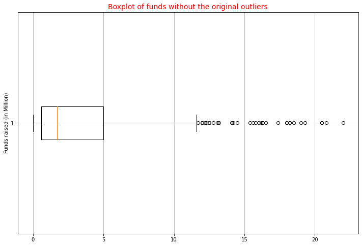

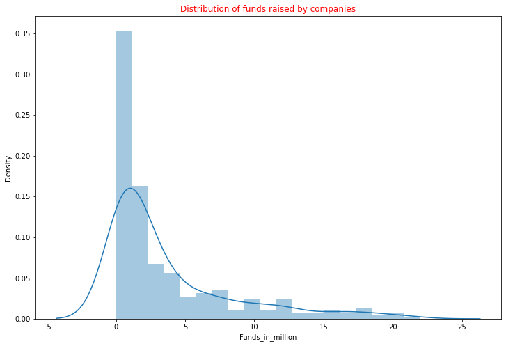

```python
import warnings
warnings.filterwarnings('ignore')
plt.figure(figsize=(12,8))
plot = plt.boxplot(df.Funds_in_million,vert=False)
plt.title('Boxplot of funds without the original outliers',color='r',fontsize=14)
plt.ylabel("Funds raised (in Million)")
plt.grid()
plt.show()
plt.figure(figsize=(12,8))
sns.distplot(df.Funds_in_million)
plt.title('Distribution of funds raised by companies',color='r')
plt.show()
```

### Using df.describe() method , we will see the exact distribution of the Funds in millions column.

```python
df.Funds_in_million.describe()
```

```
count    386.00000
mean       3.72514
std        4.73236
min        0.00500
25%        0.60000
50%        1.70000
75%        5.00000
max       22.00000
Name: Funds_in_million, dtype: float64
```

### Observations:

- Almost 75% companies have the less than 5 million raised funds and maximum value is 22 million. It shows that data is highly right skewed even after removing the outliers from the original data frame.

### E. Check frequency of the OperatingState features classes. [1 Mark]

## Ans:

```python
df.OperatingState.value_counts()
```

```
Operating    275
Closed        56
Acquired      55
Name: OperatingState, dtype: int64
```

### Observations:

- There are 275 records related to Operating state, 56 records related to Closed state and 55 records related to Acquired state.

## 4. Statistical Analysis: [10 Marks]

### A. Is there any significant difference between Funds raised by companies that are still operating vs companies that closed down? [1 Mark]

- a. Write the null hypothesis.
- b. Write down alternative hypothesis.
- c. Test for significance and conclusion.

## Ans:

### We will see the distribution of the Funds raised by the company with respective to it's Operating and Closed state.

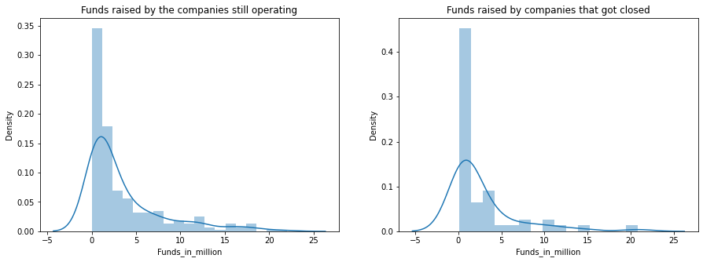

```python
fig, ax = plt.subplots(1, 2)

fig.set_figheight(5)
fig.set_figwidth(15)

sns.distplot(df.loc[df.OperatingState == 'Operating', 'Funds_in_million'], ax = ax[0])
sns.distplot(df.loc[df.OperatingState =='Closed', 'Funds_in_million'], ax = ax[1])

ax[0].set_title('Funds raised by the companies still operating')
ax[1].set_title('Funds raised by companies that got closed')
plt.show()
```

### Observations:

- Distribution of both plot is almost similar . So we can't predict about there significant difference.
- For that we will have to do the hypothesis test.
- Since our goal is to compare the difference in means, we will use 2 sample t test or z-test.
- One important point to notice is that even they don't have normal distribution but our sample size is reasonably big so we can go with it.

### B. Write the null hypothesis and alternative hypothesis. [1 Mark]

### Ans:

**Null hypothesis (Ho)** : There is no difference between the two means

**Alternate hypothesis (Ha)** : There is significant difference between the two means

### We will follow bellow step to reach at conclusion.

### Identify test :

#### This problem statement we can solve using the Independent Two Sample T-Test

### Define null and alternative hypotheses

For deciding any significant difference between Funds raised by companies that are still operating vs companies that closed down,

- the null hypothesis will be the mean of funds raised in million by the Operating company and Closed down company are same.

  > $\mu{(Operating)}$ = $\mu{(ClosedDown)}$.
- And alternative hypothesis will be mean of funds raised in million by the Operating company and Closed down company are different.

> $H_0$: $\mu{(Operating)}$ - $\mu{(ClosedDown)}$ = 0 i.e $\mu{(Operating)}$ = $\mu{(ClosedDown)}$

> $H_A$: $\mu{(Operating)}$ - $\mu{(ClosedDown)}$ $\neq$ 0 i.e $\mu{(Operating)}$ $\neq$ $\mu{(ClosedDown)}$

### Decide the significance level

#### Here we select 𝛼 = 0.05 .

### Calculate the p - value and test statistic

**We have TWO INDEPENDET samples of funds in millions of two company so we use the scipy.stats.ttest_ind to calculate the t_test . This function returns t statistic and two-tailed p value.**

**This is a two-sided test for the null hypothesis that 2 independent samples have identical average (expected) values. This test assumes that the populations have identical variances.**

## We assume that our population have identical variance.

### First , we will use Independent Two Sample T-Test:

```python
from scipy.stats import ttest_ind


sample1 = df.loc[df.OperatingState == 'Operating', 'Funds_in_million']
sample2 = df.loc[df.OperatingState =='Closed', 'Funds_in_million']

alpha = 0.05   # Let's consider a significance level of 5%

test_statistic, p_value = ttest_ind(sample1, sample2)



if p_value <= alpha:
    print(f'Since the p-value, {round(p_value, 3)} < {alpha} (alpha) the difference is significant and we reject the Null hypothesis')
else:
    print(f'''Since the p-value, {round(p_value,3)} > {alpha} (alpha) the difference is not significant and,
    we fail to reject the Null hypothesis''')
```

```
Since the p-value, 0.193 > 0.05 (alpha) the difference is not significant and,
    we fail to reject the Null hypothesis
```

### Now , we use z-test:

```python
from statsmodels.stats.weightstats import ztest

sample1 = df.loc[df.OperatingState == 'Operating', 'Funds_in_million']
sample2 = df.loc[df.OperatingState =='Closed', 'Funds_in_million']

alpha = 0.05   # Let's consider a significance level of 5%

test_statistic, p_value = ztest(sample1, sample2)

if p_value <= alpha:
    print(f'Since the p-value, {round(p_value, 3)} < {alpha} (alpha) the difference is significant and we reject the Null hypothesis')
else:
    print(f'''Since the p-value, {round(p_value,3)} > {alpha} (alpha) the difference is not significant and,
    we fail to reject the Null hypothesis''')
```

```
Since the p-value, 0.192 > 0.05 (alpha) the difference is not significant and,
    we fail to reject the Null hypothesis
```

### Thus , sample size is > 30 so both t-test and z-test giving the same result.

### Conclusion:

#### Thus from the above t-test and z-test result ,we can conclude that both Operating and Closed down company have the same mean at the 5% significance so we don't have enough evidence to say that the companies that have raised more money tend to succeed more or vice-versa.

### D. Make a copy of the original data frame. [1 Mark]

### Ans:

```python
# We have already made one copy of original data set at start of writing this code but still
# we will import again the original data frame and make copy of it.

df=pd.read_csv('DS_Part3_CompanyX_EU.csv')
df_copy=df.copy()
df_copy.head()
```

|  | Startup | Product | Funding | Event | Result | OperatingState |
| --- | --- | --- | --- | --- | --- | --- |
| 0 | 2600Hz | 2600hz.com | NaN | Disrupt SF 2013 | Contestant | Operating |
| 1 | 3DLT | 3dlt.com | $630K | Disrupt NYC 2013 | Contestant | Closed |
| 2 | 3DPrinterOS | 3dprinteros.com | NaN | Disrupt SF 2016 | Contestant | Operating |
| 3 | 3Dprintler | 3dprintler.com | $1M | Disrupt NY 2016 | Audience choice | Operating |
| 4 | 42 Technologies | 42technologies.com | NaN | Disrupt NYC 2013 | Contestant | Operating |

### E. Check frequency distribution of Result variables. [1 Mark]

### Ans

```python
df.Result.value_counts()
```

```
Contestant         488
Finalist            84
Audience choice     41
Winner              26
Runner up           23
Name: Result, dtype: int64
```

### Observation:

- There are 488 who remained contestants and the rest came out as something more as Finalist, Audience choice , Winner or Runner up . we'll call all of them winners for now.

### F. Calculate percentage of winners that are still operating and percentage of contestants that are still operating [1 Mark].

```python
winners = df.Result.value_counts()[1:].sum()
contestants = df.Result.value_counts()['Contestant']

contestants_operating = df.OperatingState[df.Result == 'Contestant'].value_counts().loc['Operating']
winners_operating = df.OperatingState[df.Result != 'Contestant'].value_counts().loc['Operating']


winners_operating/winners, contestants_operating/contestants
```

```
(0.764367816091954, 0.680327868852459)
```

### Ans:

1. Percentage of winner that are still operating is = 0.764367816091954 or 76.44%.
2. Percentage of contestant that are still operating is = 0.680327868852459 or 68.03%

### G. Write your hypothesis comparing the proportion of companies that are operating between winners and contestants: [2 Mark]

#### Note:

- There is some difference between the proportion operational companies in the two categories, but let's see if the differnce is significant or not .
- For that , we will use Z-test for proportions to check if the difference is significant or not.

### Ans:

**Null hyputhesis (Ho)**: The proportion of companies that are operating is the same in both categories - winners and contestants

**Alternative hypothesis (Ha)**: The proportion of companies that are operating is significantly different from each other, among the two categories.

```python
from statsmodels.stats.proportion import proportions_ztest

test_statistic, p_value = proportions_ztest([contestants_operating, winners_operating], [contestants, winners])

print('P_value is: ',p_value)

print('#'*40)
if p_value <= alpha:
    print(f'Since the p-value, {round(p_value, 3)} < {alpha} (alpha) the difference is significant and we reject the Null hypothesis')
else:
    print(f'''\t Since the p-value, {round(p_value,3)} > {alpha} (alpha) the difference is not significant and,
    \t we fail to reject the Null hypothesis''')
```

```
P_value is:  0.037360431984547006
########################################
Since the p-value, 0.037 < 0.05 (alpha) the difference is significant and we reject the Null hypothesis
```

### H. Test for significance and conclusion [1 Mark]

### Ans:

- The proportion of companies that are operating is significantly different from each other, among the two categories.
- So Winners in the tech-crunch battle have proven to remain operational more so, than the companies that came out only as contestants

### I. Select only the Event that has ‘disrupt’ keyword from 2013 onwards. [1 Mark]

## Ans:

```python
events = df[df.Event.apply(lambda x: 'Disrupt' in x and int(x[-4:]) > 2012)].Event

'''
Explanation of code:   we have apply the anonymous lambda function on the Event column  and in lambda function ,
we have defined that within that each event column value ,there should be Disrupt word and last four integer values which denote
year should be greater than 2012
'''
events
```

```
0          Disrupt SF 2013
1         Disrupt NYC 2013
2          Disrupt SF 2016
3          Disrupt NY 2016
4         Disrupt NYC 2013
              ...
646    Disrupt London 2015
648    Disrupt London 2015
653        Disrupt EU 2014
656       Disrupt NYC 2013
660        Disrupt SF 2013
Name: Event, Length: 276, dtype: object
```

# The End of Project.(Thank You!)